# 432 Lab 01

Steven Mayher

2022-01-24

## Package Loading

```r
library(here)
library(magrittr)
library(janitor)
library(naniar)
library(tableone)
library(patchwork)
library(knitr)
library(broom)
library(tidyverse)

theme_set(theme_bw())
```

## Import the `hbp3456` Data

```r
lab01 <- read_csv(here("labs/lab01/data", "hbp3456.csv")) %>%
    mutate(record = as.character(record))
```

# 1 Question 1

The first step that will be taken to produce this table will be to create a new field in the data set that calculates the body mass index of all of the participants by using their height and weight data (`height` and `weight` respectively). For now, this field will be named `bmi`, and has been created with the code below:

```r
lab01$bmi = round(lab01$weight/((lab01$height)^2), digits = 1)
```

Next, the `bmi` data will be used to create the other requested field that is not present in the data set, the BMI Category field, which will classify each patient into 1 of 4 body mass index categories - Underweight, Healthy weight, Overweight, and Obesity - as outlined by [this CDC article on BMI](https://www.cdc.gov/healthyweight/assessing/bmi/adult_bmi/index.html). This was accomplished with the code below, which records the results in a field called `bmi_category`, and subsequently re-levels the data for logical interpretation in the table we will be creating:

```r
lab01 = lab01 %>%
    mutate(bmi_category = case_when(bmi < 18.5 ~ "Underweight",
                                   bmi >= 18.5 & bmi < 25.0 ~ "Healthy Weight",
                                   bmi >= 25.0 & bmi < 30.0 ~ "Overweight",
                                   bmi >= 30.0 ~ "Obesity"))
lab01 = lab01 %>%
  mutate(bmi_category = fct_relevel(bmi_category,
                             "Underweight", "Healthy Weight", "Overweight", "Obesity"))
```

To check whether or not each field is formatted correctly, we’ll use the `glimpse()` function below to examine the current status of all of the fields:

```r
lab01 %>% select(age, race, eth_hisp, sex, insurance, bmi, bmi_category, sbp, dbp, practice) %>% glimpse()
```

```
Rows: 3,456
Columns: 10
$ age          <dbl> 64, 74, 60, 46, 59, 54, 74, 73, 58, 46, 49, 63, 70, 47, 6~
$ race         <chr> NA, "AA_Black", "AA_Black", "White", "AA_Black", "AA_Blac~
$ eth_hisp     <chr> NA, "No", "No", "Yes", "No", "No", "No", "No", "No", "No"~
$ sex          <chr> "F", "F", "F", "F", "M", "M", "M", "M", "F", "M", "M", "M~
$ insurance    <chr> "Medicare", "Medicare", "Commercial", "Medicaid", "Commer~
$ bmi          <dbl> 34.4, 45.0, 20.7, 23.4, 24.4, 29.7, 28.2, 25.7, 43.1, 27.~
$ bmi_category <fct> Obesity, Obesity, Healthy Weight, Healthy Weight, Healthy~
$ sbp          <dbl> 121, 93, 134, 145, 128, 138, 138, 108, 138, 135, 106, 126~
$ dbp          <dbl> 75, 46, 84, 89, 76, 86, 78, 58, 76, 82, 76, 68, 70, 81, 6~
$ practice     <chr> "Walnut", "King", "Sycamore", "Highland", "Sycamore", "El~
```

```r
lab01 = lab01 %>%
  mutate(eth_hisp = as.factor(eth_hisp)) %>%
  mutate(race = as.factor(race)) %>%
  mutate(sex = as.factor(sex)) %>%
  mutate(insurance = as.factor(insurance))
```

Examination of the actual level designations for `race` and `sex` indicates that better names could be used for them, and the `race` variable should probably be re-leveled, so this was executed below:

```r
lab01 = lab01 %>%
  mutate(race = fct_recode(factor(race), "Caucasian" = "White", "African American" = "AA_Black")) %>%
  mutate(race = fct_relevel(race, "African American", "Caucasian", "Asian", "Other")) %>%
  mutate(sex = fct_recode(factor(sex), "Male" = "M", "Female" = "F"))
```

With all of the above accomplished, we can make our subset of data that we’ll need to produce table one by filtering the data for only the Highland and Sycamore practices and selecting the relevant variables as shown below:

```r
table01_raw = lab01 %>% filter(practice != "Walnut") %>%
  filter(practice != "King") %>%
  filter(practice != "Center") %>%
  filter(practice != "Elm") %>%
  filter(practice != "North") %>%
  filter(practice != "Plympton") %>%
  select(age, race, eth_hisp, sex, insurance, bmi, bmi_category, sbp, dbp, practice)
```

Next, let’s examine if there’s any missing data in the `table01_raw` data:

```r
miss_var_summary(table01_raw)
```

```
# A tibble: 10 x 3
   variable     n_miss pct_miss
   <chr>         <int>    <dbl>
 1 eth_hisp         34    3.94
 2 race             31    3.59
 3 bmi               7    0.810
 4 bmi_category      7    0.810
 5 age               0    0
 6 sex               0    0
 7 insurance         0    0
 8 sbp               0    0
 9 dbp               0    0
10 practice          0    0
```

There’s definitely some missing data, so the code below will be used to filter out any missing data, and will also rename our variables to reflect their naming scheme from the question prompt:

```r
table01_data = table01_raw %>% filter(complete.cases(age, race, eth_hisp, sex, insurance, bmi, bmi_category, sbp, dbp, practice)) %>%
  rename("Hispanic ethnicity" = eth_hisp, "primary insurance" = insurance, "body mass index" = bmi, "BMI category" = bmi_category, "systolic blood pressure" = sbp, "diastolic blood pressure" = dbp)
```

Additionally, we’ll need to record how many records with missing data we had/removed, and the code below represents one method we can use to determine this:

```r
table01_raw_Highland = table01_raw %>% filter(practice == "Highland")
table01_raw_Sycamore = table01_raw %>% filter(practice == "Sycamore")

table01_data_Highland = table01_data %>% filter(practice == "Highland")
table01_data_Sycamore = table01_data %>% filter(practice == "Sycamore")

count(table01_raw_Highland) - count(table01_data_Highland)
```

```
  n
1 7
```

```r
count(table01_raw_Sycamore) - count(table01_data_Sycamore)
```

```
   n
1 34
```

```r
count(table01_raw) - count(table01_data)
```

```
   n
1 41
```

```r
rm(table01_raw_Highland, table01_raw_Sycamore, table01_data_Highland, table01_data_Sycamore)
```

So there’s a total of 41 records that have some form of missing data, 7 of which are from the Highland practice records, and 34 of which are from the Sycamore practice records.

With this out of the way, the last step we need to take before creating our Table 1 is to assess the normality of our quantitative variables `age`, `systolic blood pressure`, `diastolic blood pressure`, and `body mass index`, all of which will be accomplished using the following code to create a histogram, normal q-q plot, and violin box-plot for each:

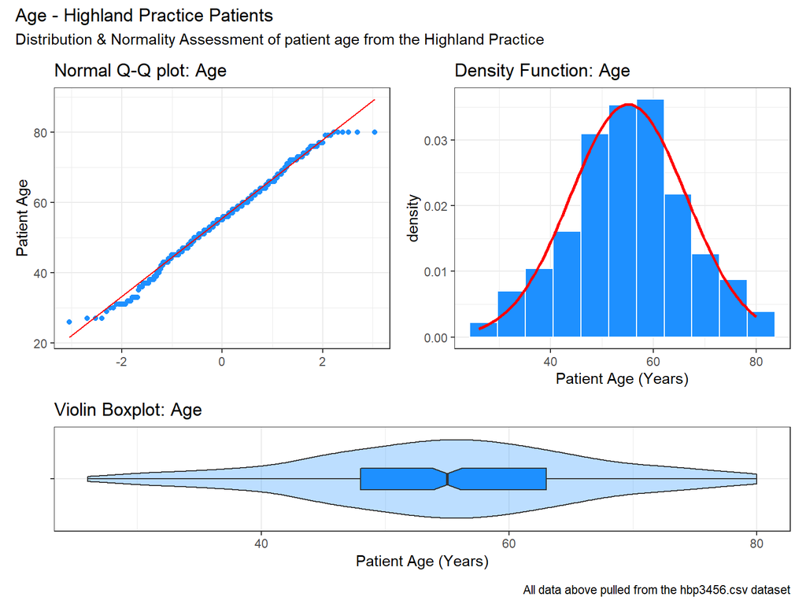

```r
table01_Highland = table01_data %>% filter(practice == "Highland")
table01_Sycamore = table01_data %>% filter(practice == "Sycamore")

a1 <- ggplot(table01_Highland, aes(x = "", y = age)) +
  geom_violin(fill = "dodgerblue", alpha = 0.3) +
  geom_boxplot(width = 0.25, fill = "dodgerblue", notch = TRUE) +
  coord_flip() +
  labs(title = "Violin Boxplot: Age", x = "", y = "Patient Age (Years)")

a2 <- ggplot(table01_Highland, aes(x = age)) +
  geom_histogram(aes(y = stat(density)), bins = nclass.scott(table01_Highland$age), col = "white", fill = "dodgerblue") +
  stat_function(fun = dnorm, args = list(mean = mean(table01_Highland$age), sd = sd(table01_Highland$age)), col = "red", lwd = 1) +
  labs(title = "Density Function: Age", x = "Patient Age (Years)")

a3 <- ggplot(table01_Highland, aes(sample = age)) +
  geom_qq(col = "dodgerblue") +
  geom_qq_line(col = "red") +
  labs(title = "Normal Q-Q plot: Age", x = "", y = "Patient Age")

p1_age_Highland = (a3 + a2) / a1 +
  plot_layout(heights = c(5,2)) +
  plot_annotation(title = "Age - Highland Practice Patients",
                  subtitle = "Distribution & Normality Assessment of patient age from the Highland Practice",
                  caption = "All data above pulled from the hbp3456.csv dataset")





a4 <- ggplot(table01_Sycamore, aes(x = "", y = age)) +
  geom_violin(fill = "dodgerblue", alpha = 0.3) +
  geom_boxplot(width = 0.25, fill = "dodgerblue", notch = TRUE) +
  coord_flip() +
  labs(title = "Violin Boxplot: Age", x = "", y = "Patient Age (Years)")

a5 <- ggplot(table01_Sycamore, aes(x = age)) +
  geom_histogram(aes(y = stat(density)), bins = nclass.scott(table01_Sycamore$age), col = "white", fill = "dodgerblue") +
  stat_function(fun = dnorm, args = list(mean = mean(table01_Sycamore$age), sd = sd(table01_Sycamore$age)), col = "red", lwd = 1) +
  labs(title = "Density Function: Age", x = "Patient Age (Years)")

a6 <- ggplot(table01_Sycamore, aes(sample = age)) +
  geom_qq(col = "dodgerblue") +
  geom_qq_line(col = "red") +
  labs(title = "Normal Q-Q plot: Age", x = "", y = "Patient Age")

p2_age_Sycamore = (a6 + a5) / a4 +
  plot_layout(heights = c(5,2)) +
  plot_annotation(title = "Age - Sycamore Practice Patients",
                  subtitle = "Distribution & Normality Assessment of `age` as pulled from the `hbp3456.csv` dataset",
                  caption = "All data above pulled from the hbp3456.csv dataset")





b1 <- ggplot(table01_Highland, aes(x = "", y = `systolic blood pressure`)) +
  geom_violin(fill = "dodgerblue", alpha = 0.3) +
  geom_boxplot(width = 0.25, fill = "dodgerblue", notch = TRUE) +
  coord_flip() +
  labs(title = "Violin Boxplot: SBP", x = "", y = "Patient Systolic Blood Pressure")

b2 <- ggplot(table01_Highland, aes(x = `systolic blood pressure`)) +
  geom_histogram(aes(y = stat(density)), bins = nclass.scott(table01_Highland$`systolic blood pressure`), col = "white", fill = "dodgerblue") +
  stat_function(fun = dnorm, args = list(mean = mean(table01_Highland$`systolic blood pressure`), sd = sd(table01_Highland$`systolic blood pressure`)), col = "red", lwd = 1) +
  labs(title = "Density Function: SBP", x = "Patient Systolic Blood Pressure")

b3 <- ggplot(table01_Highland, aes(sample = `systolic blood pressure`)) +
  geom_qq(col = "dodgerblue") +
  geom_qq_line(col = "red") +
  labs(title = "Normal Q-Q plot: SBP", x = "", y = "Patient Systolic Blood Pressure")

p3_sbp_Highland = (b3 + b2) / b1 +
  plot_layout(heights = c(5,2)) +
  plot_annotation(title = "Systolic Blood Pressure - Highland Practice Patients",
                  subtitle = "Distribution & Normality Assessment of `systolic blood pressure` as pulled from the `hbp3456.csv` dataset",
                  caption = "* SBP = Systolic Blood Pressure\nAll data above pulled from the hbp3456.csv dataset.")





b4 <- ggplot(table01_Sycamore, aes(x = "", y = `systolic blood pressure`)) +
  geom_violin(fill = "dodgerblue", alpha = 0.3) +
  geom_boxplot(width = 0.25, fill = "dodgerblue", notch = TRUE) +
  coord_flip() +
  labs(title = "Violin Boxplot: SBP", x = "", y = "Patient Systolic Blood Pressure")

b5 <- ggplot(table01_Sycamore, aes(x = `systolic blood pressure`)) +
  geom_histogram(aes(y = stat(density)), bins = nclass.scott(table01_Sycamore$`systolic blood pressure`), col = "white", fill = "dodgerblue") +
  stat_function(fun = dnorm, args = list(mean = mean(table01_Sycamore$`systolic blood pressure`), sd = sd(table01_Sycamore$`systolic blood pressure`)), col = "red", lwd = 1) +
  labs(title = "Density Function: SBP", x = "Patient Systolic Blood Pressure")

b6 <- ggplot(table01_Sycamore, aes(sample = `systolic blood pressure`)) +
  geom_qq(col = "dodgerblue") +
  geom_qq_line(col = "red") +
  labs(title = "Normal Q-Q plot: SBP", x = "", y = "Patient Systolic Blood Pressure")

p4_sbp_Sycamore = (b6 + b5) / b4 +
  plot_layout(heights = c(5,2)) +
  plot_annotation(title = "Systolic Blood Pressure - Sycamore Practice Patients",
                  subtitle = "Distribution & Normality Assessment of `systolic blood pressure` outcome as pulled from the `hbp3456.csv` dataset",
                  caption = "* SBP = Systolic Blood Pressure\nAll data above pulled from lBody Mass Index (kg/m^2) data pulled from the hbp3456.csv dataset")





c1 <- ggplot(table01_Highland, aes(x = "", y = `diastolic blood pressure`)) +
  geom_violin(fill = "dodgerblue", alpha = 0.3) +
  geom_boxplot(width = 0.25, fill = "dodgerblue", notch = TRUE) +
  coord_flip() +
  labs(title = "Violin Boxplot: DBP", x = "", y = "Patient Diastolic Blood Pressure")

c2 <- ggplot(table01_Highland, aes(x = `diastolic blood pressure`)) +
  geom_histogram(aes(y = stat(density)), bins = nclass.scott(table01_Highland$`diastolic blood pressure`), col = "white", fill = "dodgerblue") +
  stat_function(fun = dnorm, args = list(mean = mean(table01_Highland$`diastolic blood pressure`), sd = sd(table01_Highland$`diastolic blood pressure`)), col = "red", lwd = 1) +
  labs(title = "Density Function: DBP", x = "Patient Diastolic Blood Pressure")

c3 <- ggplot(table01_Highland, aes(sample = `diastolic blood pressure`)) +
  geom_qq(col = "dodgerblue") +
  geom_qq_line(col = "red") +
  labs(title = "Normal Q-Q plot: DBP", x = "", y = "Patient Diastolic Blood Pressure")

p5_dbp_Highland = (c3 + c2) / c1 +
  plot_layout(heights = c(5,2)) +
  plot_annotation(title = "Diastolic Blood Pressure - Highland Practice Patients",
                  subtitle = "Distribution & Normality Assessment of `diastolic blood pressure` outcome as pulled from the `hbp3456.csv` dataset",
                  caption = "* DBP = Diastolic Blood Pressure\nAll data above pulled from the hbp3456.csv dataset")





c4 <- ggplot(table01_Sycamore, aes(x = "", y = `diastolic blood pressure`)) +
  geom_violin(fill = "dodgerblue", alpha = 0.3) +
  geom_boxplot(width = 0.25, fill = "dodgerblue", notch = TRUE) +
  coord_flip() +
  labs(title = "Violin Boxplot: DBP", x = "", y = "Patient Diastolic Blood Pressure")

c5 <- ggplot(table01_Sycamore, aes(x = `diastolic blood pressure`)) +
  geom_histogram(aes(y = stat(density)), bins = nclass.scott(table01_Sycamore$`diastolic blood pressure`), col = "white", fill = "dodgerblue") +
  stat_function(fun = dnorm, args = list(mean = mean(table01_Sycamore$`diastolic blood pressure`), sd = sd(table01_Sycamore$`diastolic blood pressure`)), col = "red", lwd = 1) +
  labs(title = "Density Function: DBP", x = "Patient Diastolic Blood Pressure")

c6 <- ggplot(table01_Sycamore, aes(sample = `diastolic blood pressure`)) +
  geom_qq(col = "dodgerblue") +
  geom_qq_line(col = "red") +
  labs(title = "Normal Q-Q plot: DBP", x = "", y = "Patient Diastolic Blood Pressure")

p6_dbp_Sycamore = (c6 + c5) / c4 +
  plot_layout(heights = c(5,2)) +
  plot_annotation(title = "Diastolic Blood Pressure - Sycamore Practice Patients",
                  subtitle = "Distribution & Normality Assessment of `diastolic blood pressure` as pulled from the `hbp3456.csv` dataset",
                  caption = "* DBP = Diastolic Blood Pressure\nAll data above pulled from lBody Mass Index (kg/m^2) data pulled from the hbp3456.csv dataset")





d1 <- ggplot(table01_Highland, aes(x = "", y = `body mass index`)) +
  geom_violin(fill = "dodgerblue", alpha = 0.3) +
  geom_boxplot(width = 0.25, fill = "dodgerblue", notch = TRUE) +
  coord_flip() +
  labs(title = "Violin Boxplot: BMI", x = "", y = "Patient Body Mass Index (kg/m^2)")

d2 <- ggplot(table01_Highland, aes(x = `body mass index`)) +
  geom_histogram(aes(y = stat(density)), bins = nclass.scott(table01_Highland$`body mass index`), col = "white", fill = "dodgerblue") +
  stat_function(fun = dnorm, args = list(mean = mean(table01_Highland$`body mass index`), sd = sd(table01_Highland$`body mass index`)), col = "red", lwd = 1) +
  labs(title = "Density Function: BMI", x = "Patient Body Mass Index (kg/m^2)")

d3 <- ggplot(table01_Highland, aes(sample = `body mass index`)) +
  geom_qq(col = "dodgerblue") +
  geom_qq_line(col = "red") +
  labs(title = "Normal Q-Q plot: BMI", x = "", y = "Patient Body Mass Index (kg/m^2)")

p7_bmi_Highland = (d3 + d2) / d1 +
  plot_layout(heights = c(5,2)) +
  plot_annotation(title = "Body Mass Index - Highland Practice Patients",
                  subtitle = "Distribution & Normality Assessment of `body mass index` outcome as pulled from the `hbp3456.csv` dataset",
                  caption = "* BMI = Body Mass Index (kg/m^2)\nAll data above pulled from the hbp3456.csv dataset")





d4 <- ggplot(table01_Sycamore, aes(x = "", y = `body mass index`)) +
  geom_violin(fill = "dodgerblue", alpha = 0.3) +
  geom_boxplot(width = 0.25, fill = "dodgerblue", notch = TRUE) +
  coord_flip() +
  labs(title = "Violin Boxplot: BMI", x = "", y = "Patient Body Mass Index (kg/m^2)")

d5 <- ggplot(table01_Sycamore, aes(x = `body mass index`)) +
  geom_histogram(aes(y = stat(density)), bins = nclass.scott(table01_Sycamore$`body mass index`), col = "white", fill = "dodgerblue") +
  stat_function(fun = dnorm, args = list(mean = mean(table01_Sycamore$`body mass index`), sd = sd(table01_Sycamore$`body mass index`)), col = "red", lwd = 1) +
  labs(title = "Density Function: BMI", x = "Patient Body Mass Index (kg/m^2)")

d6 <- ggplot(table01_Sycamore, aes(sample = `body mass index`)) +
  geom_qq(col = "dodgerblue") +
  geom_qq_line(col = "red") +
  labs(title = "Normal Q-Q plot: BMI", x = "", y = "Patient Body Mass Index (kg/m^2)")

p8_bmi_Sycamore = (d6 + d5) / d4 +
  plot_layout(heights = c(5,2)) +
  plot_annotation(title = "Body Mass Index - Sycamore Practice Patients",
                  subtitle = "Distribution & Normality Assessment of `body mass index` outcome as pulled from the `hbp3456.csv` dataset",
                  caption = "* BMI = Body Mass Index (kg/m^2)\nAll data above pulled from lBody Mass Index (kg/m^2) data pulled from the hbp3456.csv dataset")


rm(a1, a2, a3, a4, a5, a6, b1, b2, b3, b4, b5, b6, c1, c2, c3, c4, c5, c6, d1, d2, d3, d4, d5, d6)


p1_age_Highland
```

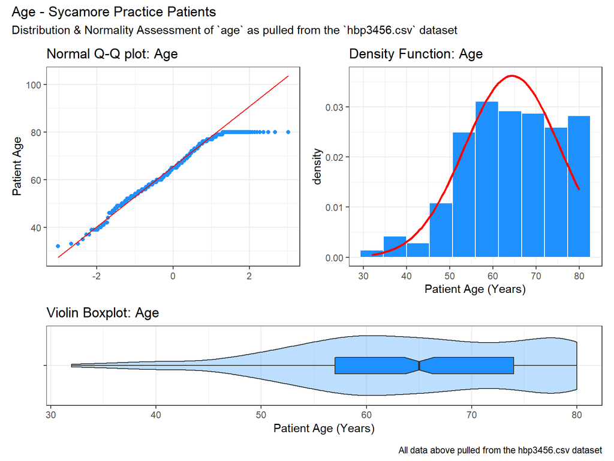

```r
p2_age_Sycamore
```

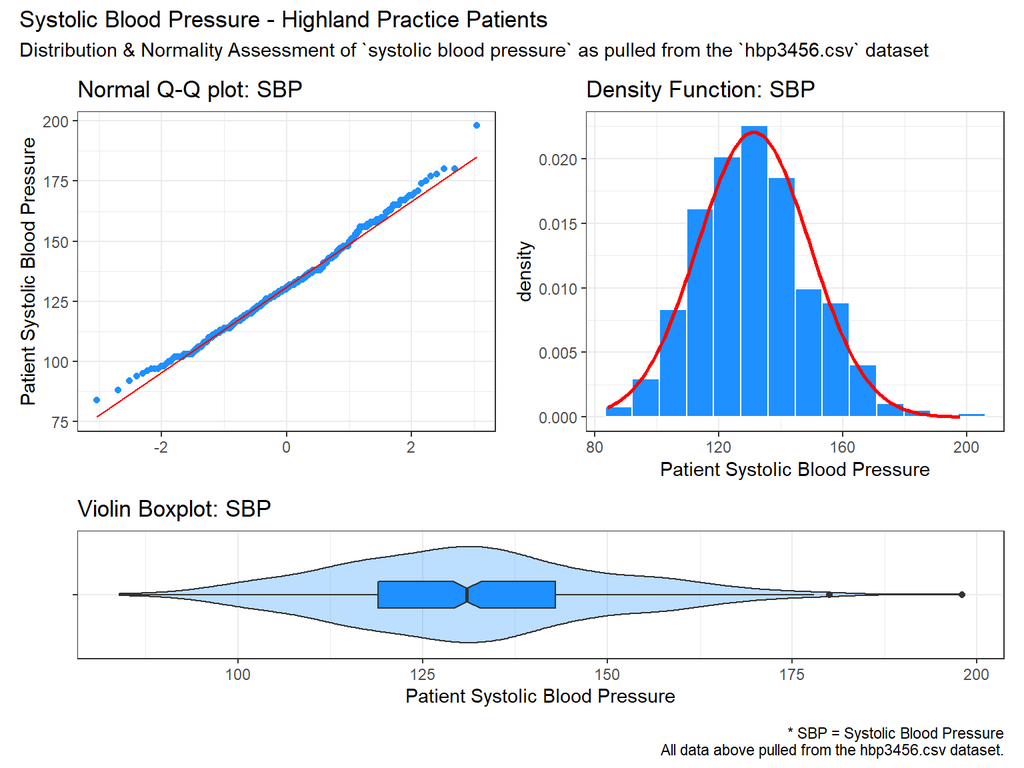

```r
p3_sbp_Highland
```

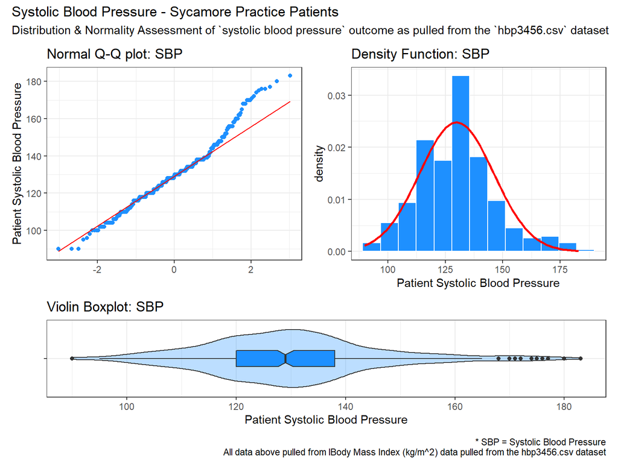

```r
p4_sbp_Sycamore
```

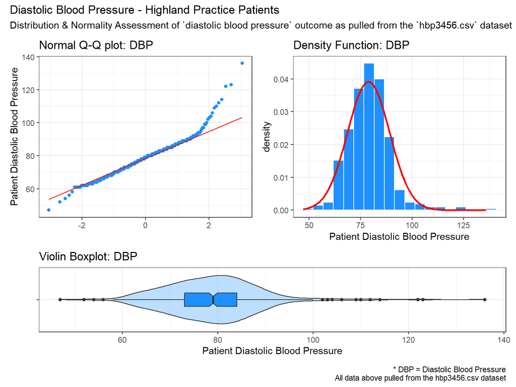

```r
p5_dbp_Highland
```

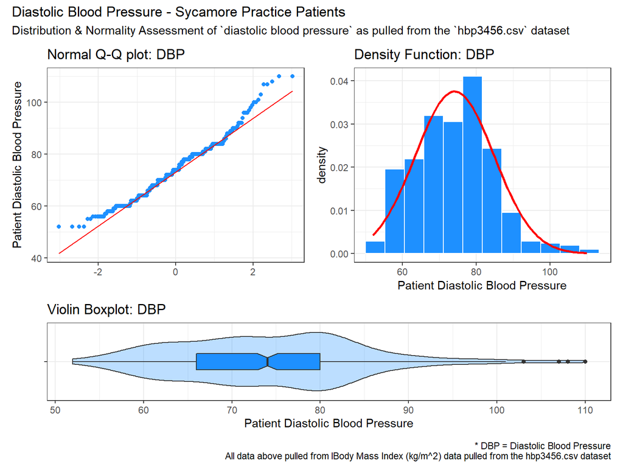

```r
p6_dbp_Sycamore
```

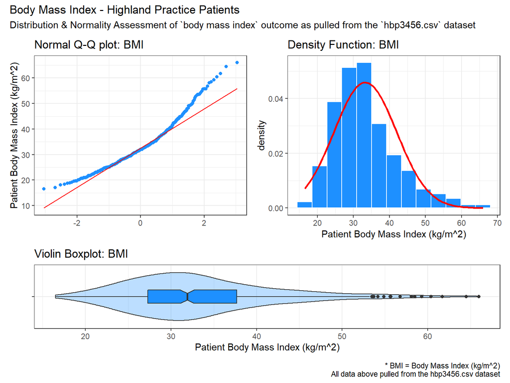

```r
p7_bmi_Highland
```

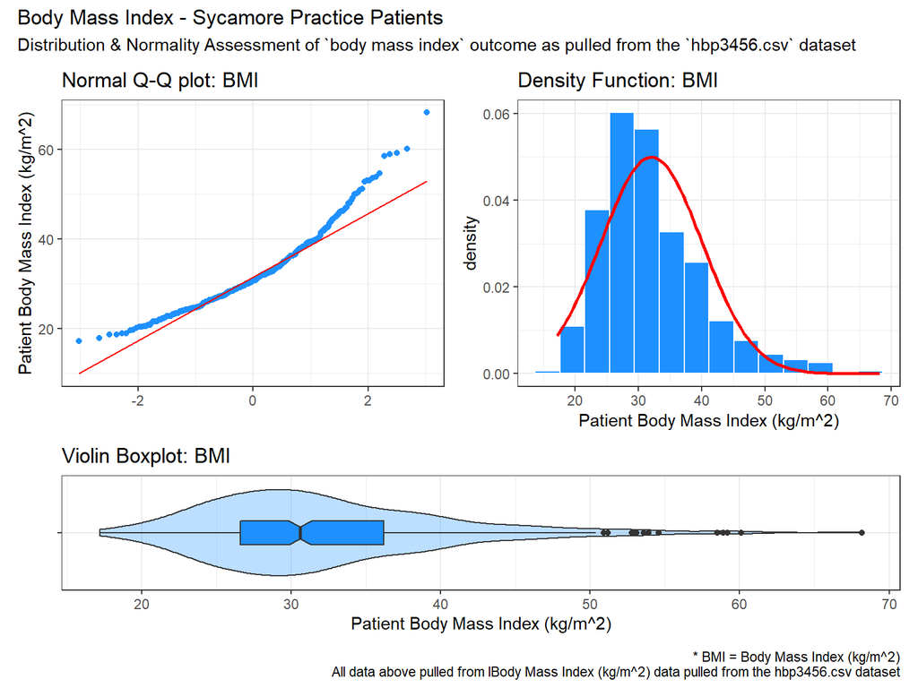

```r
p8_bmi_Sycamore
```

There appears to be some issues with normality in at least one of each of the practices’ data for all four variables, so we’ll use the non-normality option to assess each category. With all of this out of the way, we can finally create our Table 1:

```r
vars = c("age", "race", "Hispanic ethnicity", "sex", "primary insurance", "body mass index", "BMI category", "systolic blood pressure", "diastolic blood pressure")

fct.vars = c("race", "Hispanic ethnicity", "sex", "primary insurance", "BMI category")

trt = c("practice")


table01 = CreateTableOne(data = table01_data, vars = vars, factorVars = fct.vars, strata = trt, includeNA = TRUE)

print(table01, nonnormal = c("age", "systolic blood pressure", "diastolic blood pressure", "body mass index"))
```

```
                                         Stratified by practice
                                          Highland
  n                                          425
  age (median [IQR])                       55.00 [48.00, 63.00]
  race (%)
     African American                         52 (12.2)
     Caucasian                               360 (84.7)
     Asian                                    12 ( 2.8)
     Other                                     1 ( 0.2)
  Hispanic ethnicity = Yes (%)                91 (21.4)
  sex = Male (%)                             173 (40.7)
  primary insurance (%)
     Commercial                               74 (17.4)
     Medicaid                                161 (37.9)
     Medicare                                131 (30.8)
     Uninsured                                59 (13.9)
  body mass index (median [IQR])           31.90 [27.30, 37.70]
  BMI category (%)
     Underweight                               4 ( 0.9)
     Healthy Weight                           56 (13.2)
     Overweight                              107 (25.2)
     Obesity                                 258 (60.7)
  systolic blood pressure (median [IQR])  131.00 [119.00, 143.00]
  diastolic blood pressure (median [IQR])  79.00 [73.00, 84.00]
                                         Stratified by practice
                                          Sycamore                p
  n                                          398
  age (median [IQR])                       65.00 [57.00, 74.00]   <0.001
  race (%)                                                        <0.001
     African American                        335 (84.2)
     Caucasian                                53 (13.3)
     Asian                                     3 ( 0.8)
     Other                                     7 ( 1.8)
  Hispanic ethnicity = Yes (%)                 0 ( 0.0)           <0.001
  sex = Male (%)                             132 (33.2)            0.030
  primary insurance (%)                                           <0.001
     Commercial                              215 (54.0)
     Medicaid                                  0 ( 0.0)
     Medicare                                183 (46.0)
     Uninsured                                 0 ( 0.0)
```

[output cut: 17 more lines]

```
  Hispanic ethnicity = Yes (%)
  sex = Male (%)
  primary insurance (%)
     Commercial
     Medicaid
     Medicare
     Uninsured
  body mass index (median [IQR])          nonnorm
  BMI category (%)
     Underweight
     Healthy Weight
     Overweight
     Obesity
  systolic blood pressure (median [IQR])  nonnorm
  diastolic blood pressure (median [IQR]) nonnorm
```

- Again, to reiterate, there were **41** records with missing data from both practices combined, **7** of which were patients from the Highland practice, with the other **34** being patients from the Sycamore practice.

Table 1 Important Results Description:

# 2 Question 2

Before we examine whether `insurance` status meaningfully impacts `systolic blood pressure` when adjusting for whether or not the patient uses a `beta blocker`, we should start by examining the format of the data to verify whether we need to redefine or re-level any of the fields. The code below lets us confirm the field types as they are now:

```r
lab01 %>% select(insurance, sbp, betab) %>% glimpse()
```

```
Rows: 3,456
Columns: 3
$ insurance <fct> Medicare, Medicare, Commercial, Medicaid, Commercial, Commer~
$ sbp       <dbl> 121, 93, 134, 145, 128, 138, 138, 108, 138, 135, 106, 126, 1~
$ betab     <chr> "No", "No", "Yes", "No", "No", "No", "No", "Yes", "No", "No"~
```

The insurance variable is already formatted as a factor from the previous question, so the only field that needs redefining is the beta-blocker field `betab`. The code below redefines the field as a factor, and for good measure also re-levels the field to insure that the “Yes” category will be listed first in our analyses:

```r
lab01 = lab01 %>%
  mutate(betab = as.factor(betab)) %>%
  mutate(betab = fct_relevel(betab, "Yes", "No")) %>%
  mutate(insurance = fct_relevel(insurance, "Uninsured", "Medicaid", "Medicare", "Commercial"))

lab01 %>% select(insurance, sbp, betab) %>% glimpse()
```

```
Rows: 3,456
Columns: 3
$ insurance <fct> Medicare, Medicare, Commercial, Medicaid, Commercial, Commer~
$ sbp       <dbl> 121, 93, 134, 145, 128, 138, 138, 108, 138, 135, 106, 126, 1~
$ betab     <fct> No, No, Yes, No, No, No, No, Yes, No, No, No, Yes, Yes, No, ~
```

With this accomplished, we can create our sub-set of data for this analysis and check for missing-ness below:

```r
q2_data = lab01 %>% select(insurance, sbp, betab)

miss_var_summary(q2_data)
```

```
# A tibble: 3 x 3
  variable  n_miss pct_miss
  <chr>      <int>    <dbl>
1 insurance      0        0
2 sbp            0        0
3 betab          0        0
```

The results above indicate that we do not have any missing data for these fields, so we’ll proceed with the analyses. We’ll start by simply checking if we should transform the systolic blood pressure data:

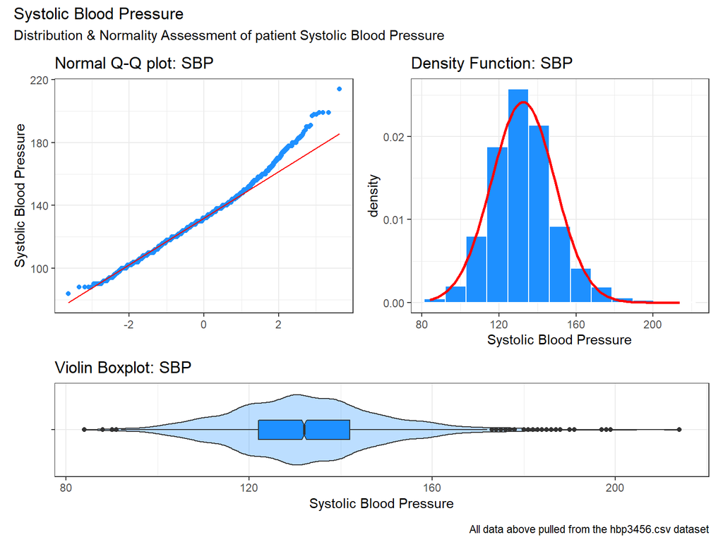

```r
a1 <- ggplot(q2_data, aes(x = "", y = sbp)) +
  geom_violin(fill = "dodgerblue", alpha = 0.3) +
  geom_boxplot(width = 0.25, fill = "dodgerblue", notch = TRUE) +
  coord_flip() +
  labs(title = "Violin Boxplot: SBP", x = "", y = "Systolic Blood Pressure")

a2 <- ggplot(q2_data, aes(x = sbp)) +
  geom_histogram(aes(y = stat(density)), bins = nclass.Sturges(q2_data$sbp), col = "white", fill = "dodgerblue") +
  stat_function(fun = dnorm, args = list(mean = mean(q2_data$sbp), sd = sd(q2_data$sbp)), col = "red", lwd = 1) +
  labs(title = "Density Function: SBP", x = "Systolic Blood Pressure")

a3 <- ggplot(q2_data, aes(sample = sbp)) +
  geom_qq(col = "dodgerblue") +
  geom_qq_line(col = "red") +
  labs(title = "Normal Q-Q plot: SBP", x = "", y = "Systolic Blood Pressure")

q2_sbp = (a3 + a2) / a1 +
  plot_layout(heights = c(5,2)) +
  plot_annotation(title = "Systolic Blood Pressure",
                  subtitle = "Distribution & Normality Assessment of patient Systolic Blood Pressure",
                  caption = "All data above pulled from the hbp3456.csv dataset")

rm(a1, a2, a3)

q2_sbp
```

The histogram, normal q-q plot, and violin box-plot above all suggest some issues with normality, specifically some right-skew. Let’s see which transformation would be most appropriate by evaluating them all:

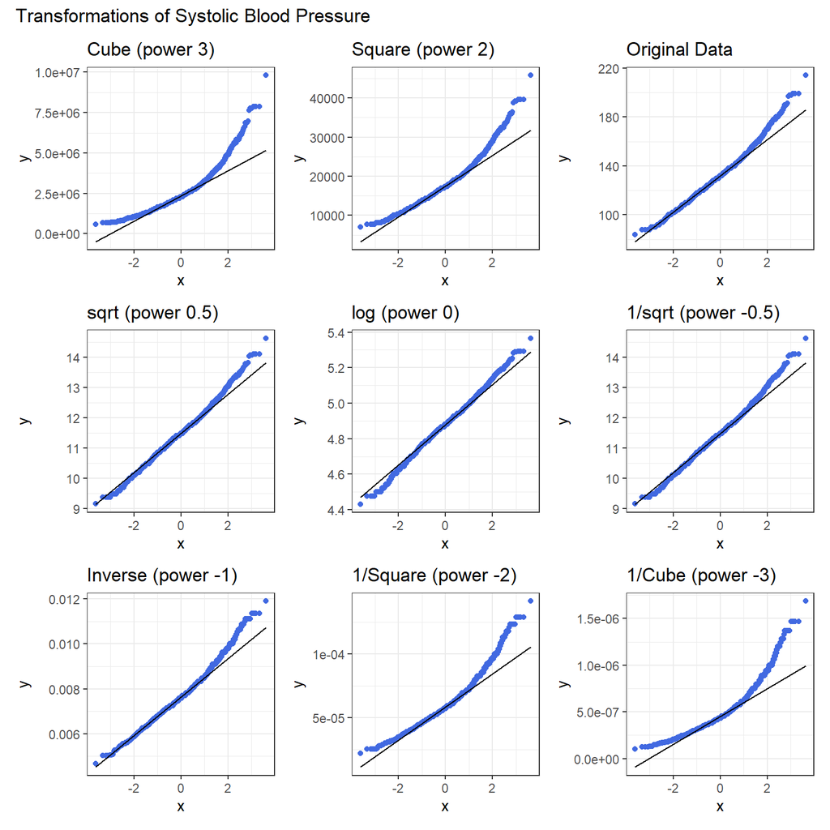

```r
p1 <- ggplot(q2_data, aes(sample = sbp^3)) +
    geom_qq(col = "royalblue") +
    geom_qq_line(col = "black") +
    labs(title = "Cube (power 3)")

p2 <- ggplot(q2_data, aes(sample = sbp^2)) +
    geom_qq(col = "royalblue") +
    geom_qq_line(col = "black") +
    labs(title = "Square (power 2)")

p3 <- ggplot(q2_data, aes(sample = sbp)) +
    geom_qq(col = "royalblue") +
    geom_qq_line(col = "black") +
    labs(title = "Original Data")

p4 <- ggplot(q2_data, aes(sample = sqrt(sbp))) +
    geom_qq(col = "royalblue") +
    geom_qq_line(col = "black") +
    labs(title = "sqrt (power 0.5)")

p5 <- ggplot(q2_data, aes(sample = log(sbp))) +
    geom_qq(col = "royalblue") +
    geom_qq_line(col = "black") +
    labs(title = "log (power 0)")

p6 <- ggplot(q2_data, aes(sample = sbp^(0.5))) +
    geom_qq(col = "royalblue") +
    geom_qq_line(col = "black") +
    labs(title = "1/sqrt (power -0.5)")

p7 <- ggplot(q2_data, aes(sample = 1/sbp)) +
    geom_qq(col = "royalblue") +
    geom_qq_line(col = "black") +
    labs(title = "Inverse (power -1)")

p8 <- ggplot(q2_data, aes(sample = 1/(sbp^2))) +
    geom_qq(col = "royalblue") +
    geom_qq_line(col = "black") +
    labs(title = "1/Square (power -2)")

p9 <- ggplot(q2_data, aes(sample = 1/(sbp^3))) +
    geom_qq(col = "royalblue") +
    geom_qq_line(col = "black") +
    labs(title = "1/Cube (power -3)")

p1 + p2 + p3 + p4 + p5 + p6 + p7 + p8 + p9 +
    plot_layout(nrow = 3) +
    plot_annotation(title = "Transformations of Systolic Blood Pressure")
```

```r
rm(p1, p2, p3, p4, p5, p6, p7, p8, p9)
```

It seems a log transformation would be most appropriate - we could use a log function to transform the data every time we want to analyze it, however we’ll instead create a new variable for it in the `q2_data` table:

```r
q2_data$log_sbp = log(q2_data$sbp)
```

Let’s examine the transformation using the same kind of histogram, normal q-q plot, and violin box-plot from earlier:

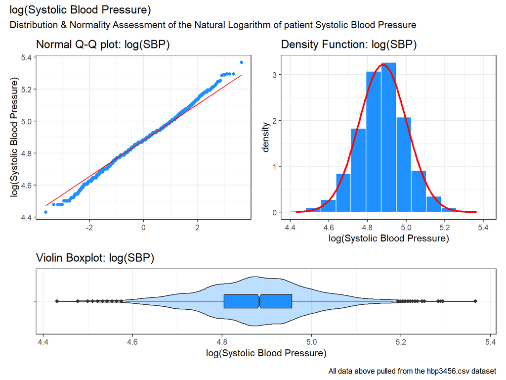

```r
a1 <- ggplot(q2_data, aes(x = "", y = log_sbp)) +
  geom_violin(fill = "dodgerblue", alpha = 0.3) +
  geom_boxplot(width = 0.25, fill = "dodgerblue", notch = TRUE) +
  coord_flip() +
  labs(title = "Violin Boxplot: log(SBP)", x = "", y = "log(Systolic Blood Pressure)")

a2 <- ggplot(q2_data, aes(x = log_sbp)) +
  geom_histogram(aes(y = stat(density)), bins = nclass.Sturges(q2_data$log_sbp), col = "white", fill = "dodgerblue") +
  stat_function(fun = dnorm, args = list(mean = mean(q2_data$log_sbp), sd = sd(q2_data$log_sbp)), col = "red", lwd = 1) +
  labs(title = "Density Function: log(SBP)", x = "log(Systolic Blood Pressure)")

a3 <- ggplot(q2_data, aes(sample = log_sbp)) +
  geom_qq(col = "dodgerblue") +
  geom_qq_line(col = "red") +
  labs(title = "Normal Q-Q plot: log(SBP)", x = "", y = "log(Systolic Blood Pressure)")

q2_log_sbp = (a3 + a2) / a1 +
  plot_layout(heights = c(5,2)) +
  plot_annotation(title = "log(Systolic Blood Pressure)",
                  subtitle = "Distribution & Normality Assessment of the Natural Logarithm of patient Systolic Blood Pressure",
                  caption = "All data above pulled from the hbp3456.csv dataset")

rm(a1, a2, a3)

q2_log_sbp
```

There appears to still be a number of outliers, however this appears to be a better linear fit than the original systolic blood pressures, so we will use `log_sbp` moving forward.

Next, lets create a table and plot of the means of `log_sbp` in eight combinations - two levels for beta-blocker prescription status `betab` combined with the four insurance categories:

```r
summaries_1 <- q2_data %>%
  group_by(insurance, betab) %>%
  summarise(n = n(), mean = mean(log_sbp),
            stdev = sd(log_sbp))
summaries_1 %>% kable(digits = 2)
```

| insurance | betab | n | mean | stdev |
| --- | --- | --- | --- | --- |
| Uninsured | Yes | 45 | 4.89 | 0.13 |
| Uninsured | No | 89 | 4.88 | 0.14 |
| Medicaid | Yes | 289 | 4.90 | 0.14 |
| Medicaid | No | 618 | 4.88 | 0.12 |
| Medicare | Yes | 595 | 4.88 | 0.13 |
| Medicare | No | 787 | 4.87 | 0.12 |
| Commercial | Yes | 289 | 4.89 | 0.12 |
| Commercial | No | 744 | 4.87 | 0.12 |

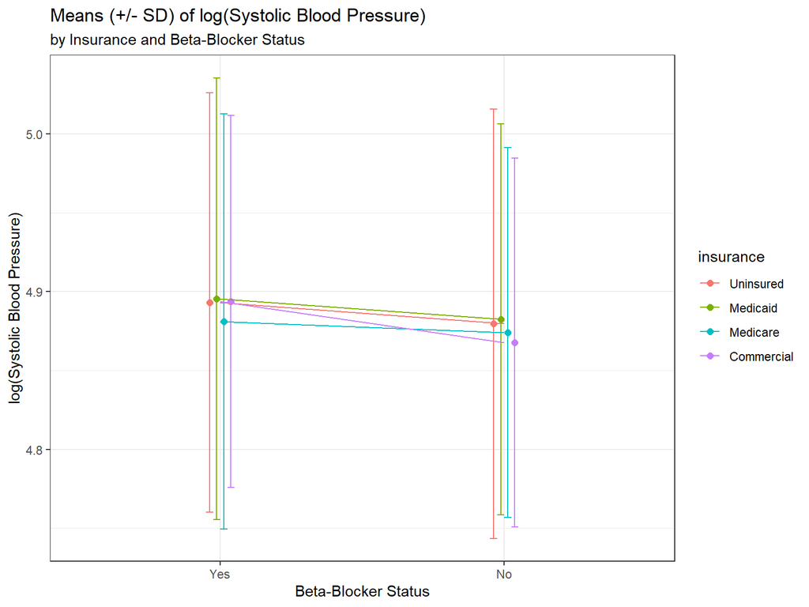

```r
pd = position_dodge(0.1)

ggplot(summaries_1, aes(x = betab, y = mean, col = insurance)) +
  geom_errorbar(aes(ymin = mean - stdev, ymax = mean + stdev),
                width = 0.1, position = pd) +
  geom_point(size = 2,
             position = pd) +
  geom_line(aes(group = insurance)) +
  labs(y = "log(Systolic Blood Pressure)",
       x = "Beta-Blocker Status",
       title = "Means (+/- SD) of log(Systolic Blood Pressure)",
       subtitle = "by Insurance and Beta-Blocker Status")
```

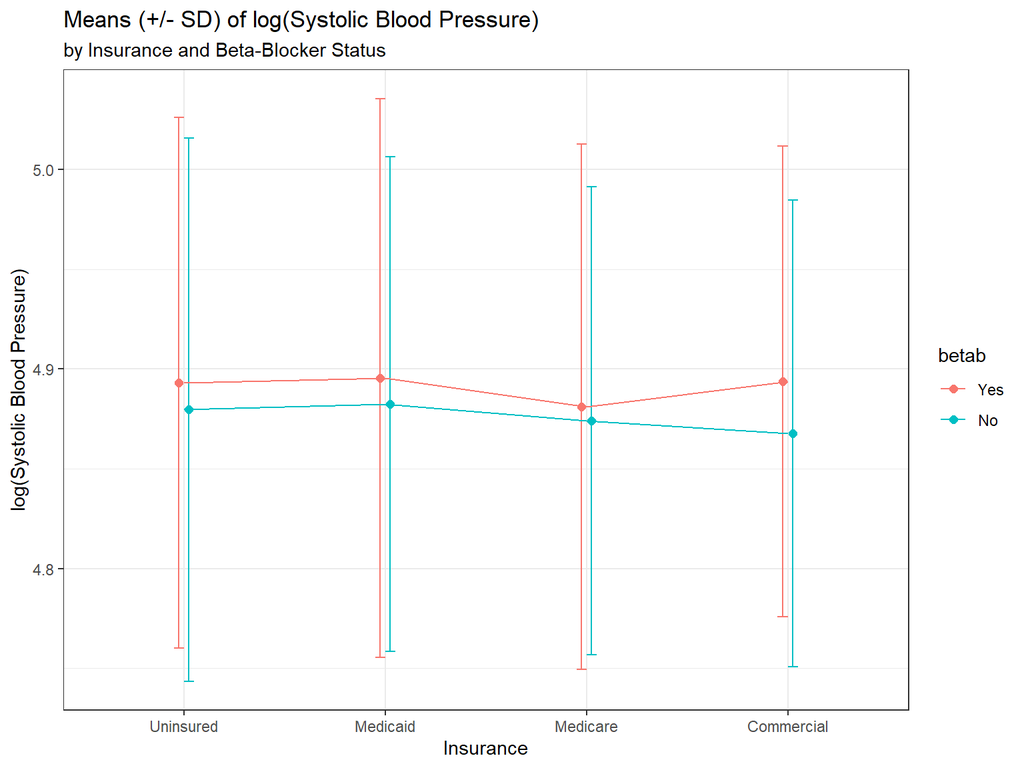

```r
pd = position_dodge(0.1)

ggplot(summaries_1, aes(x = insurance, y = mean, col = betab)) +
  geom_errorbar(aes(ymin = mean - stdev, ymax = mean + stdev),
                width = 0.1, position = pd) +
  geom_point(size = 2,
             position = pd) +
  geom_line(aes(group = betab)) +
  labs(y = "log(Systolic Blood Pressure)",
       x = "Insurance",
       title = "Means (+/- SD) of log(Systolic Blood Pressure)",
       subtitle = "by Insurance and Beta-Blocker Status")
```

Both of the graphs above indicate that some an interaction effect between `insurance` and `betab` may be occurring, as the lines do not run entirely parallel to each other. As such, a model that designates `betab` as an interaction term would likely be the better choice. As such, we’ll create this model below and examine it’s overall quality of fit and will interpret the coefficients for this model. First, to create the model:

```r
m1 = lm(log_sbp ~ insurance*betab, data = q2_data)
```

Next, to assess it’s quality of fit and interpret the coefficients:

```r
anova(m1)
```

```
Analysis of Variance Table

Response: log_sbp
                  Df Sum Sq  Mean Sq F value   Pr(>F)
insurance          3  0.078 0.025961  1.6946 0.165969
betab              1  0.152 0.151590  9.8951 0.001671 **
insurance:betab    3  0.047 0.015767  1.0292 0.378458
Residuals       3448 52.822 0.015320
---
Signif. codes:  0 '***' 0.001 '**' 0.01 '*' 0.05 '.' 0.1 ' ' 1
```

```r
glance(m1)
```

```
# A tibble: 1 x 12
  r.squared adj.r.squared sigma statistic p.value    df logLik    AIC    BIC
      <dbl>         <dbl> <dbl>     <dbl>   <dbl> <dbl>  <dbl>  <dbl>  <dbl>
1   0.00521       0.00319 0.124      2.58  0.0118     7  2321. -4624. -4568.
# ... with 3 more variables: deviance <dbl>, df.residual <int>, nobs <int>
```

```r
q2_data = q2_data %>%
  mutate(betab = fct_relevel(betab, "No", "Yes"))

m1 = lm(log_sbp ~ insurance*betab, data = q2_data)

tidy(m1, conf.int = TRUE, conf.level = 0.90) %>%
    select(term, estimate,
           low90 = conf.low, high90 = conf.high,
           se = std.error, p = p.value) %>%
    kable(digits = c(0,3,3,2,2,3))
```

| term | estimate | low90 | high90 | se | p |
| --- | --- | --- | --- | --- | --- |
| (Intercept) | 4.880 | 4.858 | 4.90 | 0.01 | 0.000 |
| insuranceMedicaid | 0.003 | -0.020 | 0.03 | 0.01 | 0.835 |
| insuranceMedicare | -0.006 | -0.028 | 0.02 | 0.01 | 0.686 |
| insuranceCommercial | -0.012 | -0.035 | 0.01 | 0.01 | 0.391 |
| betabYes | 0.013 | -0.024 | 0.05 | 0.02 | 0.553 |
| insuranceMedicaid:betabYes | 0.000 | -0.040 | 0.04 | 0.02 | 0.984 |
| insuranceMedicare:betabYes | -0.006 | -0.045 | 0.03 | 0.02 | 0.790 |
| insuranceCommercial:betabYes | 0.013 | -0.027 | 0.05 | 0.02 | 0.597 |

To assess the quality of fit for this model, we’ll compare it to the fit to a non-interaction model:

```r
m1_no = lm(log_sbp ~ insurance + betab, data = q2_data)

comp_table <- bind_rows( glance(m1), glance(m1_no) ) %>%
  mutate(mod = c("m1", "m1_no"))

comp_table %>% select(mod, r.squared, adj.r.squared, sigma, AIC, BIC) %>%
  kable(dig = c(0, 5, 5, 3, 1, 1))
```

| mod | r.squared | adj.r.squared | sigma | AIC | BIC |
| --- | --- | --- | --- | --- | --- |
| m1 | 0.00521 | 0.00319 | 0.124 | -4623.6 | -4568.3 |
| m1_no | 0.00432 | 0.00317 | 0.124 | -4626.5 | -4589.6 |

# 3 Question 3

An important idea that resonates with me from Jeff Leek’s **How To Be a Modern Scientist** is the necessity of having a career plan and developing a career trajectory. When I completed my undergraduate education, I admittedly didn’t spend much time considering my career trajectory until my final year of the program, and despite the time I did spend considering this moving forward I wasn’t entirely certain what to do next once I finished my degree. I had originally wanted to major in biology because I wanted to help people in a medical setting, however I wasn’t really sure in what capacity I’d like to do that, and while my coursework and college advising was excellent at educating me on the subject matter, it wasn’t great at providing me any insight into this matter, much like Jeff Leek remarks on page 70 in the Career Planning section of the book:

“Sometimes I feel like this altruism has negative consequences. For example, I think that there is less emphasis on the career planning and development side in the academic community. I don’t think this is malicious, but…being brilliant and good at science is not enough. You also need to pay attention to and plan carefully your career trajectory.”

It took me some time to figure out a plan, but after working here at Case and continuing my education as a non-degree Grad Student, I finally gained some direction, and know what direction I want to develop my career towards, however I know the contents of this section (and honestly the whole book) will help me to continue to refine this and also help me in many other ways (such as writing a thesis) as I continue through and complete the Systems Biology and Bioinformatics program.

# 4 Question 4

My github name is StevenMayher.